# (Clean) Vehicle Data

Glorija

2024-06-21

## Introduction

This is a presentation of my findings while investigating the dataset car_prices

### The dataset has been cleaned and filtered:

- Removed irrelevant columns such as: trim, vin, body, state, interior, body, seller, and sell date;
- Cleared non-sensical data, missing values, and NAs;
- Made unique makes and colors uniform;
- Converted variables into factors & normalised

## Summary & Structure

```r
summary(data)
```

```
##       year          make              odometer         color
##  Min.   :1984   Length:511711      Min.   :     1   Length:511711
##  1st Qu.:2008   Class :character   1st Qu.: 28430   Class :character
##  Median :2012   Mode  :character   Median : 51838   Mode  :character
##  Mean   :2010                      Mean   : 67566
##  3rd Qu.:2013                      3rd Qu.: 97762
##  Max.   :2015                      Max.   :999999
##       mmr          sellingprice    transmission         condition
##  Min.   :    25   Min.   :     1   Length:511711      Min.   : 1.00
##  1st Qu.:  7300   1st Qu.:  7000   Class :character   1st Qu.:23.00
##  Median : 12300   Median : 12200   Mode  :character   Median :34.00
##  Mean   : 13806   Mean   : 13651                      Mean   :30.57
##  3rd Qu.: 18300   3rd Qu.: 18200                      3rd Qu.:41.00
##  Max.   :182000   Max.   :230000                      Max.   :49.00
```

```r
head(data)
```

```
##   year   make odometer color   mmr sellingprice transmission condition
## 1 2015    kia    16639 white 20500        21500    automatic         5
## 2 2015    kia     9393 white 20800        21500    automatic         5
## 3 2014    bmw     1331  gray 31900        30000    automatic        45
## 4 2015  volvo    14282 white 27500        27750    automatic        41
## 5 2014    bmw     2641  gray 66000        67000    automatic        43
## 6 2015 nissan     5554  gray 15350        10900    automatic         1
```

```r
str(data)
```

```
## 'data.frame':    511711 obs. of  8 variables:
##  $ year        : int  2015 2015 2014 2015 2014 2015 2014 2014 2014 2014 ...
##  $ make        : chr  "kia" "kia" "bmw" "volvo" ...
##  $ odometer    : int  16639 9393 1331 14282 2641 5554 14943 28617 9557 4809 ...
##  $ color       : chr  "white" "white" "gray" "white" ...
##  $ mmr         : int  20500 20800 31900 27500 66000 15350 69000 11900 32100 26300 ...
##  $ sellingprice: int  21500 21500 30000 27750 67000 10900 65000 9800 32250 17500 ...
##  $ transmission: chr  "automatic" "automatic" "automatic" "automatic" ...
##  $ condition   : int  5 5 45 41 43 1 34 2 42 3 ...
```

## Correlation & Feature Selection

### Correlation Matrix (char & num)

- Cramer’s V for Categorical vs Categorical comparison
- Pearson’s for Numerical vs Numerical comparison
- Cramer’s V for Categorical vs Numerical comparison

```
##                year  make odometer color    mmr sellingprice transmission
## year          1.000 0.403   -0.773 0.337  0.593        0.583        0.244
## make          0.403 1.000    0.214 0.282  0.635        0.623        0.403
## odometer     -0.773 0.214    1.000 0.187 -0.584       -0.578        0.120
## color         0.337 0.282    0.187 1.000  0.194        0.161        0.245
## mmr           0.593 0.635   -0.584 0.194  1.000        0.984        0.117
## sellingprice  0.583 0.623   -0.578 0.161  0.984        1.000        0.091
## transmission  0.244 0.403    0.120 0.245  0.117        0.091        1.000
## condition     0.537 0.221    0.316 0.189  0.284        0.239        0.208
##              condition
## year             0.537
## make             0.221
## odometer         0.316
## color            0.189
## mmr              0.284
## sellingprice     0.239
## transmission     0.208
## condition        1.000
```

### Correlation Matrix Continued (char & num)

- Some of the correlation coefficient’s are below 0.2, so I increased the threshold and filtered out the small correlations

```
## [1] "year"         "make"         "odometer"     "mmr"          "sellingprice"
## [6] "condition"
```

```
##                year   make odometer    mmr condition sellingprice
## year          1.000 -0.011   -0.773  0.593     0.356        0.583
## make         -0.011  1.000   -0.022 -0.065     0.033       -0.063
## odometer     -0.773 -0.022    1.000 -0.584    -0.338       -0.578
## mmr           0.593 -0.065   -0.584  1.000     0.301        0.984
## condition     0.356  0.033   -0.338  0.301     1.000        0.344
## sellingprice  0.583 -0.063   -0.578  0.984     0.344        1.000
```

### PCA (char & num)

```
## Importance of components:
##                           PC1    PC2    PC3    PC4     PC5    PC6
## Standard deviation     1.8032 1.0149 0.8953 0.8223 0.47512 0.1225
## Proportion of Variance 0.5419 0.1717 0.1336 0.1127 0.03762 0.0025
## Cumulative Proportion  0.5419 0.7136 0.8472 0.9599 0.99750 1.0000
```

```
##                 PC1    PC2    PC3    PC4    PC5    PC6
## year         -0.462  0.080  0.032 -0.521  0.712  0.021
## make          0.022  0.937 -0.315  0.147  0.031  0.000
## odometer      0.458 -0.115  0.008  0.535  0.701 -0.001
## mmr          -0.497 -0.147 -0.290  0.385  0.009 -0.707
## condition    -0.284  0.251  0.870  0.313 -0.022 -0.038
## sellingprice -0.498 -0.135 -0.244  0.418 -0.012  0.706
```

```
##   Principal_Component Variance_Explained
## 1                 PC1         54.1918858
## 2                 PC2         17.1673249
## 3                 PC3         13.3601557
## 4                 PC4         11.2683595
## 5                 PC5          3.7622722
## 6                 PC6          0.2500018
```

### Correlation Matrix (num)

- Seeing as there are many PCs and it takes about 4 of them to explain most of the data, I have decided to do correlation with just numerical variables (low correlation) and see if PCA improves

```
##                year odometer    mmr sellingprice
## year          1.000   -0.773  0.593        0.583
## odometer     -0.773    1.000 -0.584       -0.578
## mmr           0.593   -0.584  1.000        0.984
## sellingprice  0.583   -0.578  0.984        1.000
```

### PCA (num)

```
## Importance of components:
##                           PC1    PC2     PC3     PC4
## Standard deviation     1.7471 0.8395 0.47614 0.12739
## Proportion of Variance 0.7631 0.1762 0.05668 0.00406
## Cumulative Proportion  0.7631 0.9393 0.99594 1.00000
```

```
##                 PC1    PC2    PC3    PC4
## year         -0.478 -0.515  0.711 -0.013
## odometer      0.476  0.529  0.703 -0.003
## mmr          -0.523  0.471  0.003  0.710
## sellingprice -0.521  0.483 -0.014 -0.704
```

```
##   Principal_Component Variance_Explained
## 1                 PC1         76.3060869
## 2                 PC2         17.6203358
## 3                 PC3          5.6678479
## 4                 PC4          0.4057294
```

### Correlation & Feature Selection Conclusion

- Numerical variables explain the data better and the dimensions are reduced therefore, categorical variables have been filtered out for a better model

## Regression Models

### Linear Regression

```
##
## Call:
## lm(formula = response ~ ., data = as.data.frame(predictors))
##
## Residuals:
##     Min      1Q  Median      3Q     Max
## -8.9777 -0.0675  0.0100  0.0822 21.4964
##
## Coefficients:
##               Estimate Std. Error t value Pr(>|t|)
## (Intercept)  9.189e-16  2.513e-04    0.00        1
## year        -8.716e-03  4.122e-04  -21.15   <2e-16 ***
## odometer    -1.169e-02  4.088e-04  -28.59   <2e-16 ***
## mmr          9.820e-01  3.220e-04 3050.17   <2e-16 ***
## ---
## Signif. codes:  0 '***' 0.001 '**' 0.01 '*' 0.05 '.' 0.1 ' ' 1
##
## Residual standard error: 0.1798 on 511707 degrees of freedom
## Multiple R-squared:  0.9677, Adjusted R-squared:  0.9677
## F-statistic: 5.108e+06 on 3 and 511707 DF,  p-value: < 2.2e-16
```

```
## Linear Regression RMSE: 0.1749224
```

```
## Linear Regression R-squared: 0.9676856
```

### Polynomial Regression

```
##
## Call:
## lm(formula = sellingprice ~ poly(year, 2) + poly(odometer, 2) +
##     poly(mmr, 2), data = as.data.frame(train_data))
##
## Residuals:
##     Min      1Q  Median      3Q     Max
## -8.8690 -0.0673  0.0110  0.0824 21.4976
##
## Coefficients:
##                      Estimate Std. Error  t value Pr(>|t|)
## (Intercept)         7.101e-04  2.827e-04    2.512    0.012 *
## poly(year, 2)1     -7.827e+00  3.265e-01  -23.970  < 2e-16 ***
## poly(year, 2)2     -2.336e+00  1.928e-01  -12.114  < 2e-16 ***
## poly(odometer, 2)1 -7.853e+00  3.201e-01  -24.535  < 2e-16 ***
## poly(odometer, 2)2  8.533e-01  1.976e-01    4.319 1.57e-05 ***
## poly(mmr, 2)1       6.311e+02  2.471e-01 2553.583  < 2e-16 ***
## poly(mmr, 2)2      -3.148e+00  2.055e-01  -15.318  < 2e-16 ***
## ---
## Signif. codes:  0 '***' 0.001 '**' 0.01 '*' 0.05 '.' 0.1 ' ' 1
##
## Residual standard error: 0.1809 on 409363 degrees of freedom
## Multiple R-squared:  0.9675, Adjusted R-squared:  0.9675
## F-statistic: 2.028e+06 on 6 and 409363 DF,  p-value: < 2.2e-16
```

```
## Polynomial Regression RMSE: 0.1749021
```

```
## Polynomial Regression R-squared: 0.9674528
```

### Model Comparison

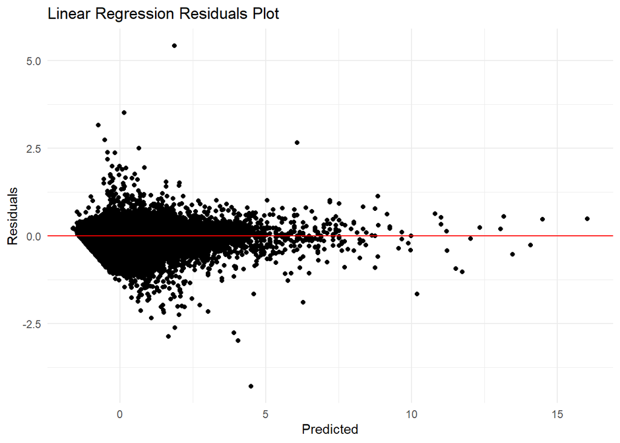

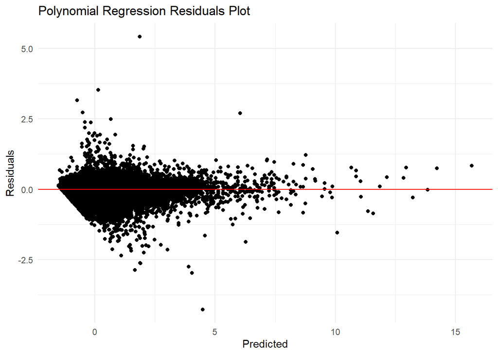